# Session 4

# DemoTools

## Installation

To install, use the devtools package. It might take a bit of time if dependencies need to be installed.

```r
library(devtools)
install_github("timriffe/DemoTools")
```

Get started using the help files (note the graphs are made using base…). Here’s an example of `sprague()` used to split population counts arranges in an age-period matrix:

```r
library(DemoTools)
head(pop5_mat) # this is the entire matrix
```

```
##     1950  1951  1952  1953  1954
## 0  54170 57424 60272 62727 64816
## 5  44775 44475 44780 45681 47137
## 10 42142 41752 41804 42101 42508
## 15 38464 39628 40229 40474 40532
## 20 34406 34757 35155 35599 36083
## 25 30386 30605 30978 31439 31940
```

```r
# the last value is an open age group, preserve as such:
p1 <- sprague(pop5_mat, OAG = TRUE)
colSums(p1) - colSums(pop5_mat)
```

```
## 1950 1951 1952 1953 1954
##    0    0    0    0    0
```

## Example of `sprague()`

Using `sprague()` as a smoother. Note, it’s constrained in 5-year age groups. It smooths nicely if heaping is equally bad on 0s and 5s, but not if its magnitude differs. See the wavy pattern in older ages?

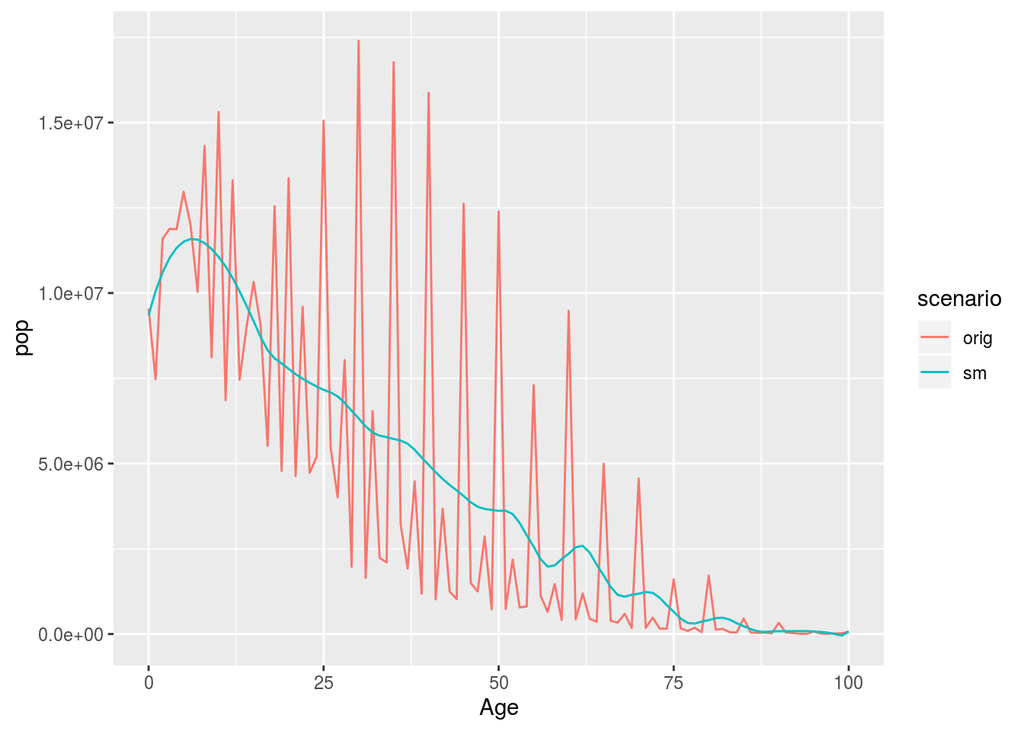

```r
# another case, starting with single ages
Age         <- 0:100
# notice how this particular case produces a negative value in the last age
# before OAG:
pops <- sprague(popmat = pop1m_ind, Age = Age, OAG = TRUE)

# this we wrote in calss though:
data.frame(Age = Age,
           orig = pop1m_ind,
           sm = pops) %>%
  gather(key = "scenario", value = "pop",
         2:3) %>%
  ggplot(mapping = aes(x = Age, y = pop, color = scenario)) +
  geom_line()
```

There are other functions one could use to similar effect: `beers()`, `groupAges()` with `splitMono()`, `splitUniform()` (a utility)

An example of group + constrained split:

```r
P5 <- groupAges(pop1m_pasex, Age=0:99)
splitMono(P5, Age = seq(0,95,by=5))
```

```
##          0          1          2          3          4          5
##  99678.232  99881.864  99780.048  99372.784  98660.072  99892.064
##          6          7          8          9         10         11
## 101327.688  99846.256  95447.768  88132.224  79771.400  73355.280
##         12         13         14         15         16         17
##  68507.080  65226.800  63514.440  62205.248  59850.776  56891.552
##         18         19         20         21         22         23
##  53327.576  49158.848  43566.152  38376.624  35323.048  34405.424
##         24         25         26         27         28         29
##  35623.752  37261.344  37474.968  37059.696  36015.528  34342.464
##         30         31         32         33         34         35
##  32393.496  30863.792  29747.944  29045.952  28757.816  28590.256
##         36         37         38         39         40         41
##  28146.792  27522.464  26717.272  25731.216  24655.160  23699.680
##         42         43         44         45         46         47
##  22879.200  22193.720  21643.240  20931.592  20129.944  19570.048
##         48         49         50         51         52         53
##  19251.904  19175.512  19418.112  19499.544  19102.488  18226.944
##         54         55         56         57         58         59
##  16872.912  15172.480  13791.040  12929.200  12586.960  12764.320
##         60         61         62         63         64         65
##  13336.960  13563.200  13196.520  12236.920  10684.400   8646.664
##         66         67         68         69         70         71
##   7004.208   6089.576   5902.768   6443.784   7292.656   7656.312
##         72         73         74         75         76         77
##   7558.184   6998.272   5976.576   4777.072   3885.424   3260.488
##         78         79         80         81         82         83
##   2902.264   2810.752   2664.648   2340.736   2098.712   1938.576
##         84         85         86         87         88         89
##   1860.328   1775.296   1635.672   1506.224   1386.952   1277.856
##         90         91         92         93         94         95
##   1159.928   1035.216    923.752    825.536    740.568    618.080
##         96         97         98         99
##    486.760    411.720    392.960    430.480
```